# Part I - Ford GoBike Exploration

## Introduction

The dataset contains information about individual rides made in a bike-sharing system covering the greater San Francisco Bay area, information such as duration, start and end time as well as start and end station are recorded. These various attributes will be explored in this report to find insights into the data and find any correlations that exist from it using Python and its various data analysis libraries.

## Preliminary Wrangling

Before embarking on the exploration, the dataset will be explored quickly to wrangle it and ensure it is in the right format for analysis.

```python
# import all packages and set plots to be embedded inline
import numpy as np
import pandas as pd
import matplotlib.pyplot as plt
import seaborn as sb

%matplotlib inline
```

> Load in your dataset and describe its properties through the questions below. Try and motivate your exploration goals through this section.

```python
# reading the csv file into a dataframe and printing out the first 5 rows to view the dataset
fordbike = pd.read_csv("201902-fordgobike-tripdata.csv")
fordbike.head()
```

|  | duration_sec | start_time | end_time | start_station_id | start_station_name | start_station_latitude | start_station_longitude | end_station_id | end_station_name | end_station_latitude | end_station_longitude | bike_id | user_type | member_birth_year | member_gender | bike_share_for_all_trip |
| --- | --- | --- | --- | --- | --- | --- | --- | --- | --- | --- | --- | --- | --- | --- | --- | --- |
| 0 | 52185 | 2019-02-28 17:32:10.1450 | 2019-03-01 08:01:55.9750 | 21.0 | Montgomery St BART Station (Market St at 2nd St) | 37.789625 | -122.400811 | 13.0 | Commercial St at Montgomery St | 37.794231 | -122.402923 | 4902 | Customer | 1984.0 | Male | No |
| 1 | 42521 | 2019-02-28 18:53:21.7890 | 2019-03-01 06:42:03.0560 | 23.0 | The Embarcadero at Steuart St | 37.791464 | -122.391034 | 81.0 | Berry St at 4th St | 37.775880 | -122.393170 | 2535 | Customer | NaN | NaN | No |
| 2 | 61854 | 2019-02-28 12:13:13.2180 | 2019-03-01 05:24:08.1460 | 86.0 | Market St at Dolores St | 37.769305 | -122.426826 | 3.0 | Powell St BART Station (Market St at 4th St) | 37.786375 | -122.404904 | 5905 | Customer | 1972.0 | Male | No |
| 3 | 36490 | 2019-02-28 17:54:26.0100 | 2019-03-01 04:02:36.8420 | 375.0 | Grove St at Masonic Ave | 37.774836 | -122.446546 | 70.0 | Central Ave at Fell St | 37.773311 | -122.444293 | 6638 | Subscriber | 1989.0 | Other | No |
| 4 | 1585 | 2019-02-28 23:54:18.5490 | 2019-03-01 00:20:44.0740 | 7.0 | Frank H Ogawa Plaza | 37.804562 | -122.271738 | 222.0 | 10th Ave at E 15th St | 37.792714 | -122.248780 | 4898 | Subscriber | 1974.0 | Male | Yes |

```python
#showing the column types of the dataset
fordbike.dtypes
```

```
duration_sec                 int64
start_time                  object
end_time                    object
start_station_id           float64
start_station_name          object
start_station_latitude     float64
start_station_longitude    float64
end_station_id             float64
end_station_name            object
end_station_latitude       float64
end_station_longitude      float64
bike_id                      int64
user_type                   object
member_birth_year          float64
member_gender               object
bike_share_for_all_trip     object
dtype: object
```

```python
fordbike.describe()
```

|  | duration_sec | start_station_id | start_station_latitude | start_station_longitude | end_station_id | end_station_latitude | end_station_longitude | bike_id | member_birth_year |
| --- | --- | --- | --- | --- | --- | --- | --- | --- | --- |
| count | 183412.000000 | 183215.000000 | 183412.000000 | 183412.000000 | 183215.000000 | 183412.000000 | 183412.000000 | 183412.000000 | 175147.000000 |
| mean | 726.078435 | 138.590427 | 37.771223 | -122.352664 | 136.249123 | 37.771427 | -122.352250 | 4472.906375 | 1984.806437 |
| std | 1794.389780 | 111.778864 | 0.099581 | 0.117097 | 111.515131 | 0.099490 | 0.116673 | 1664.383394 | 10.116689 |
| min | 61.000000 | 3.000000 | 37.317298 | -122.453704 | 3.000000 | 37.317298 | -122.453704 | 11.000000 | 1878.000000 |
| 25% | 325.000000 | 47.000000 | 37.770083 | -122.412408 | 44.000000 | 37.770407 | -122.411726 | 3777.000000 | 1980.000000 |
| 50% | 514.000000 | 104.000000 | 37.780760 | -122.398285 | 100.000000 | 37.781010 | -122.398279 | 4958.000000 | 1987.000000 |
| 75% | 796.000000 | 239.000000 | 37.797280 | -122.286533 | 235.000000 | 37.797320 | -122.288045 | 5502.000000 | 1992.000000 |
| max | 85444.000000 | 398.000000 | 37.880222 | -121.874119 | 398.000000 | 37.880222 | -121.874119 | 6645.000000 | 2001.000000 |

```python
# checking the dataset for null values
fordbike.isnull().sum()
```

```
duration_sec                  0
start_time                    0
end_time                      0
start_station_id            197
start_station_name          197
start_station_latitude        0
start_station_longitude       0
end_station_id              197
end_station_name            197
end_station_latitude          0
end_station_longitude         0
bike_id                       0
user_type                     0
member_birth_year          8265
member_gender              8265
bike_share_for_all_trip       0
dtype: int64
```

```python
# checking for duplicates
fordbike.duplicated().sum()
```

```
0
```

By checking the columns types, it can be seen that there are some columns which are having the wrong type and will have to be changed. The changes to be made include

1. start_time --> datetime
2. end_time --> datetime
3. start_station_id --> int64
4. end_station_id --> int64
5. member_birth_year --> int64

It can also be seen that for certain columns there are some missing values which could affect the data exploration and at this time will be removed

```python
#dropping null rows
drop_ids = fordbike[fordbike["member_gender"].isnull()].index
fordbike.drop(drop_ids,axis=0,inplace=True)
#fordbike.reset_index().drop( index ,axis=1,inplace=True)
```

```python
#checking for null values
fordbike.isnull().sum()
```

```
duration_sec                 0
start_time                   0
end_time                     0
start_station_id           195
start_station_name         195
start_station_latitude       0
start_station_longitude      0
end_station_id             195
end_station_name           195
end_station_latitude         0
end_station_longitude        0
bike_id                      0
user_type                    0
member_birth_year            0
member_gender                0
bike_share_for_all_trip      0
dtype: int64
```

```python
#dropping remaining null rows
drop_ids = fordbike[fordbike["start_station_id"].isnull()].index
fordbike.drop(drop_ids,axis=0,inplace=True)
fordbike.reset_index(inplace=True)
fordbike.drop("index",axis=1,inplace=True)
```

```python
#checking for null values
fordbike.isnull().sum()
```

```
duration_sec               0
start_time                 0
end_time                   0
start_station_id           0
start_station_name         0
start_station_latitude     0
start_station_longitude    0
end_station_id             0
end_station_name           0
end_station_latitude       0
end_station_longitude      0
bike_id                    0
user_type                  0
member_birth_year          0
member_gender              0
bike_share_for_all_trip    0
dtype: int64
```

```python
# conversion of columns to datatime

fordbike["start_time"] = pd.to_datetime(fordbike["start_time"])
fordbike["end_time"] = pd.to_datetime(fordbike["end_time"])
```

```python
# conversion of columns from float to int

fordbike["start_station_id"] = fordbike["start_station_id"].astype(int)
fordbike["end_station_id"] = fordbike["end_station_id"].astype(int)
fordbike["member_birth_year"] = fordbike["member_birth_year"].astype(int)
```

```python
# checking to see if datatypes has been changed as intended
fordbike.dtypes
```

```
duration_sec                        int64
start_time                 datetime64[ns]
end_time                   datetime64[ns]
start_station_id                    int32
start_station_name                 object
start_station_latitude            float64
start_station_longitude           float64
end_station_id                      int32
end_station_name                   object
end_station_latitude              float64
end_station_longitude             float64
bike_id                             int64
user_type                          object
member_birth_year                   int32
member_gender                      object
bike_share_for_all_trip            object
dtype: object
```

In addition, 2 new columns to contain the month of the start and end time as well as 2 more columns for the weekday from the start and end time as this could be further explored during the course of the exploration

```python
# creating the month columns

fordbike["start_month"] = fordbike["start_time"].dt.month
fordbike["end_month"] = fordbike["end_time"].dt.month
```

```python
# creating the weekday columns

fordbike["start_weekday"] = fordbike["start_time"].dt.day_name()
fordbike["end_weekday"] = fordbike["end_time"].dt.day_name()
```

```python
# creating age column
data_year = 2019
fordbike['age'] = data_year - fordbike['member_birth_year']
```

```python
# checking the new column set
fordbike.head()
```

|  | duration_sec | start_time | end_time | start_station_id | start_station_name | start_station_latitude | start_station_longitude | end_station_id | end_station_name | end_station_latitude | ... | bike_id | user_type | member_birth_year | member_gender | bike_share_for_all_trip | start_month | end_month | start_weekday | end_weekday | age |
| --- | --- | --- | --- | --- | --- | --- | --- | --- | --- | --- | --- | --- | --- | --- | --- | --- | --- | --- | --- | --- | --- |
| 0 | 52185 | 2019-02-28 17:32:10.145 | 2019-03-01 08:01:55.975 | 21 | Montgomery St BART Station (Market St at 2nd St) | 37.789625 | -122.400811 | 13 | Commercial St at Montgomery St | 37.794231 | ... | 4902 | Customer | 1984 | Male | No | 2 | 3 | Thursday | Friday | 35 |
| 1 | 61854 | 2019-02-28 12:13:13.218 | 2019-03-01 05:24:08.146 | 86 | Market St at Dolores St | 37.769305 | -122.426826 | 3 | Powell St BART Station (Market St at 4th St) | 37.786375 | ... | 5905 | Customer | 1972 | Male | No | 2 | 3 | Thursday | Friday | 47 |
| 2 | 36490 | 2019-02-28 17:54:26.010 | 2019-03-01 04:02:36.842 | 375 | Grove St at Masonic Ave | 37.774836 | -122.446546 | 70 | Central Ave at Fell St | 37.773311 | ... | 6638 | Subscriber | 1989 | Other | No | 2 | 3 | Thursday | Friday | 30 |
| 3 | 1585 | 2019-02-28 23:54:18.549 | 2019-03-01 00:20:44.074 | 7 | Frank H Ogawa Plaza | 37.804562 | -122.271738 | 222 | 10th Ave at E 15th St | 37.792714 | ... | 4898 | Subscriber | 1974 | Male | Yes | 2 | 3 | Thursday | Friday | 45 |
| 4 | 1793 | 2019-02-28 23:49:58.632 | 2019-03-01 00:19:51.760 | 93 | 4th St at Mission Bay Blvd S | 37.770407 | -122.391198 | 323 | Broadway at Kearny | 37.798014 | ... | 5200 | Subscriber | 1959 | Male | No | 2 | 3 | Thursday | Friday | 60 |

5 rows × 21 columns

```python
# printing out the new shape of the
fordbike.shape,fordbike.columns
```

```
((174952, 21),
 Index(['duration_sec', 'start_time', 'end_time', 'start_station_id',
        'start_station_name', 'start_station_latitude',
        'start_station_longitude', 'end_station_id', 'end_station_name',
        'end_station_latitude', 'end_station_longitude', 'bike_id', 'user_type',
        'member_birth_year', 'member_gender', 'bike_share_for_all_trip',
        'start_month', 'end_month', 'start_weekday', 'end_weekday', 'age'],
       dtype='object'))
```

```python
#selecting the columns needed for the investigation
fordbike_origin = fordbike.copy()
fordbike = fordbike[['duration_sec','start_time','end_time',
        'start_station_name', 'end_station_name', 'user_type',
        'age', 'member_gender', 'bike_share_for_all_trip',
        'start_month', 'end_month', 'start_weekday', 'end_weekday']]
fordbike.to_csv("wrangled_ford_gobike_data.csv")
```

```python
fordbike.shape
```

```
(174952, 13)
```

### What is the structure of your dataset?

The dataset after wrangling is comprised of 13 columns of about 170000 rows, with no null values as they have been dropped

### What is/are the main feature(s) of interest in your dataset?

1. Which station was used the most to start?
2. Which station was did most people end up?
3. Is there a particular month or period(seasons) in which people biked a whole lot?
4. Is there a relationship between duration and gender?
5. Is there a relationship between duration and month/season?
6. As the day when by did the number of biker and duration increase?

### What features in the dataset do you think will help support your investigation into your feature(s) of interest?

duration_sec , start_time , end_time , start_station_id , start_station_name, end_station_id , end_station_name, user_type , member_birth_year , member_gender , bike_share_for_all_trip , start_month , end_month , start_weekday , end_weekday

## Univariate Exploration

#### Univariate functions

Fuctions for plotting different univariate charts

```python
def bar_chart(data,x,order,hor=False):
    plt.figure(figsize=(10,8))
    chart_col = sb.color_palette()[0]
    if hor == False:
        sb.countplot(data=data,x=x,order=order,color=chart_col)
    else:
        sb.countplot(data=data,y=x,order=order,color=chart_col)

def plt_bar_chart(data,x,y):
    plt.figure(figsize=(10,8))
    plt.bar(data=data,x=x,height=y)
```

```python
#creating a copy for univariate exploration
fordbike_uni = fordbike.copy()
```

#### Question 1:

Exploring which station did most individuals start their journey from

```python
fordbike_uni['start_station_name'].value_counts()
```

```
Market St at 10th St                                         3649
San Francisco Caltrain Station 2  (Townsend St at 4th St)    3408
Berry St at 4th St                                           2952
Montgomery St BART Station (Market St at 2nd St)             2711
Powell St BART Station (Market St at 4th St)                 2620
                                                             ...
Farnam St at Fruitvale Ave                                      9
Parker Ave at McAllister St                                     7
21st Ave at International Blvd                                  4
Palm St at Willow St                                            3
16th St Depot                                                   2
Name: start_station_name, Length: 329, dtype: int64
```

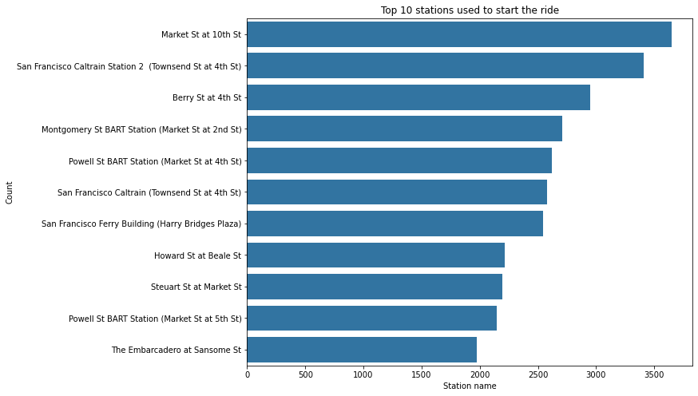

```python
# obtaining the index of the top ten stations that people started with
order = fordbike_uni['start_station_name'].value_counts().iloc[:11].index
bar_chart(fordbike_uni,'start_station_name',order=order,hor=True)
plt.title("Top 10 stations used to start the ride")
plt.xlabel("Station name")
plt.ylabel("Count")
plt.show()
```

From the visualization above, it can be seen that the station most used to start the journey is 'Market St at 10th St'

#### Question 2:

Which station did most people end up at?

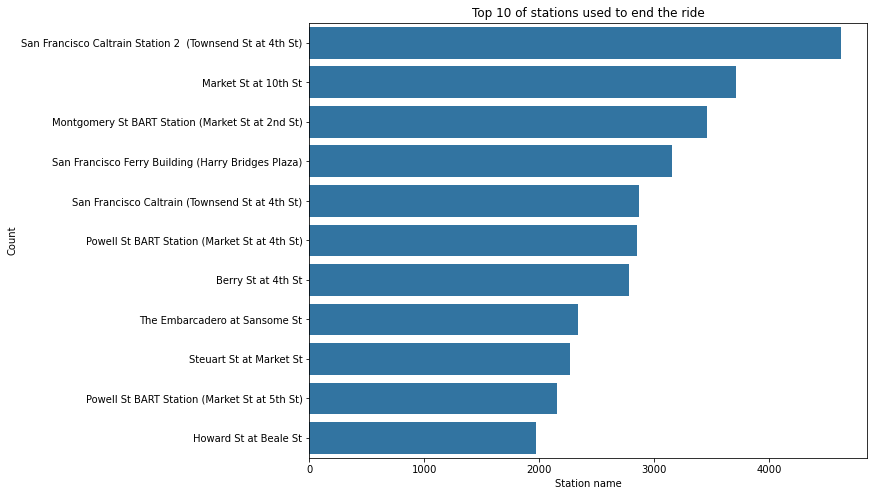

```python
# obtaining the index of the top ten stations that people ended with
order = fordbike_uni['end_station_name'].value_counts().iloc[:11].index

bar_chart(fordbike_uni,'end_station_name',order=order,hor=True)
plt.title("Top 10 of stations used to end the ride")
plt.xlabel("Station name")
plt.ylabel("Count")
plt.show()
```

From this view, we observe that the station that most people ended at is 'San Francisco Caltrain Station 2 (Townsend St at 4th St)'

#### Question 3

Exploring the user type in the dataset and the ratio

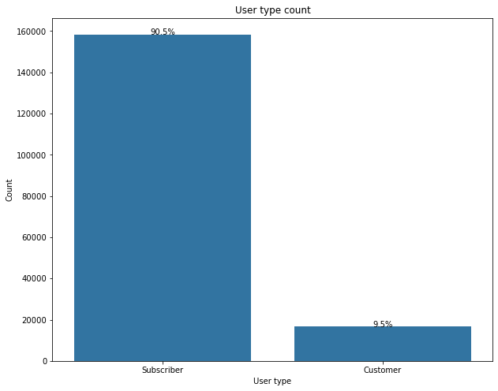

```python
#plotting a bar chart for visualization
x = fordbike_uni['user_type'].value_counts()
order=fordbike_uni['user_type'].value_counts().index
bar_chart(fordbike_uni,'user_type',order=order)
plt.title('User type count')
plt.xlabel('User type')
plt.ylabel('Count')
locs, labels = plt.xticks()
num = fordbike_uni['user_type'].value_counts().sum()

# loop through each pair of locations and labels
for loc, label in zip(locs, labels):
    # get the text property for the label to get the correct count
    count = x[label.get_text()]
    pct_string = '{:0.1f}%'.format(100*count/num)
    # print the annotation just below the top of the bar
    plt.text(loc, count, pct_string, ha = 'center', color = 'black')
plt.show()
```

From the visualization, we can see that in the given dataset, approx 91% are subscribers while the remaining are customers

#### Question 4

Gender

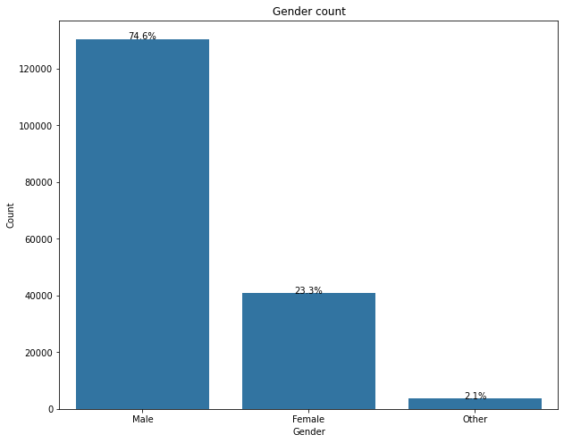

```python
x = fordbike_uni['member_gender'].value_counts()
num = x.sum()
order=fordbike_uni['member_gender'].value_counts().index
bar_chart(fordbike_uni,'member_gender',order=order)
plt.title('Gender count')
plt.xlabel('Gender')
plt.ylabel('Count')
locs, labels = plt.xticks()
for loc, label in zip(locs, labels):
    # get the text property for the label to get the correct count
    count = x[label.get_text()]
    pct_string = '{:0.1f}%'.format(100*count/num)
    # print the annotation just below the top of the bar
    plt.text(loc, count, pct_string, ha = 'center', color = 'black')

plt.show()
```

With this visualization, we can see that male gender are the predominantly bike riders as they account for up to 75%

#### Bike share for all

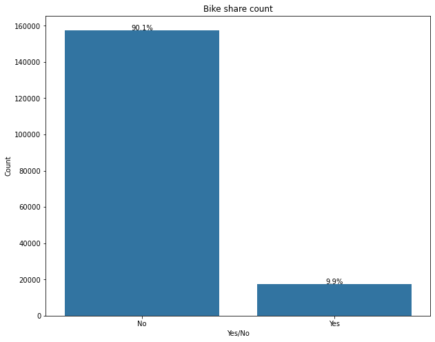

```python
x = fordbike_uni['bike_share_for_all_trip'].value_counts()
order =fordbike_uni['bike_share_for_all_trip'].value_counts().index
num = x.sum()
bar_chart(fordbike_uni,'bike_share_for_all_trip',order=order)
plt.title('Bike share count')
plt.xlabel('Yes/No')
plt.ylabel('Count')
locs, labels = plt.xticks()
for loc, label in zip(locs, labels):
    # get the text property for the label to get the correct count
    count = x[label.get_text()]
    pct_string = '{:0.1f}%'.format(100*count/num)
    # print the annotation just below the top of the bar
    plt.text(loc, count, pct_string, ha = 'center', color = 'black')
plt.show()
```

With this we can see that only a few number of individuals were willing to share their bike

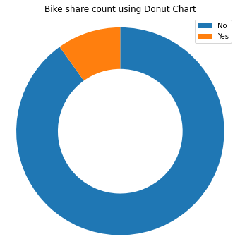

```python
#Plotting a pie chart to better show the ratio
plt.figure(figsize=(10,6))
sorted_counts = fordbike_uni['bike_share_for_all_trip'].value_counts()
plt.pie(sorted_counts, startangle = 90,counterclock = False, wedgeprops = {'width' : 0.4})
plt.axis('square')
plt.title('Bike share count using Donut Chart')
plt.legend(sorted_counts.index)
plt.show()
```

#### Question 5

Month and Weekday

```python
#creating a list of weekdays in an order
days=['Monday','Tuesday','Wednesday','Thursday','Friday','Saturday','Sunday']
#creating a new dataframe consisting of the information about the weekdays
start_wk = fordbike_uni['start_weekday'].value_counts().rename_axis('Weekday').reset_index(name='Count')
start_wk["Weekday"] = start_wk["Weekday"].astype("category").cat.set_categories(days)
start_wk.sort_values('Weekday',inplace=True)
start_wk.reset_index(inplace=True)
start_wk.drop('index',axis=1,inplace=True)
```

```python
start_wk['Count'][0]
```

```
25641
```

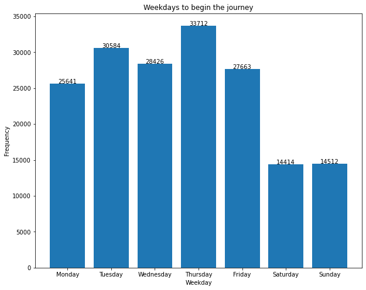

```python
plt_bar_chart(start_wk,'Weekday','Count')
#plt.bar(data=start_wk,x='Weekday',height='Count')
plt.title('Weekdays to begin the journey')
plt.xlabel('Weekday')
plt.ylabel('Frequency')
locs, labels= plt.xticks()
for loc in locs:
    # get the text property for the label to get the correct count
    count = start_wk['Count'][loc]
    pct_string = f'{count}'
    # print the annotation just below the top of the bar
    plt.text(loc, count, pct_string, ha = 'center', color = 'black')
plt.show()
```

```python
#creating a list of weekdays in an order
days=['Monday','Tuesday','Wednesday','Thursday','Friday','Saturday','Sunday']
#creating a new dataframe consisting of the information about the weekdays
end_wk = fordbike_uni['end_weekday'].value_counts().rename_axis('Weekday').reset_index(name='Count')
end_wk["Weekday"] = end_wk["Weekday"].astype("category").cat.set_categories(days)
end_wk.sort_values('Weekday',inplace=True)
end_wk.reset_index(inplace=True)
end_wk.drop('index',axis=1,inplace=True)
```

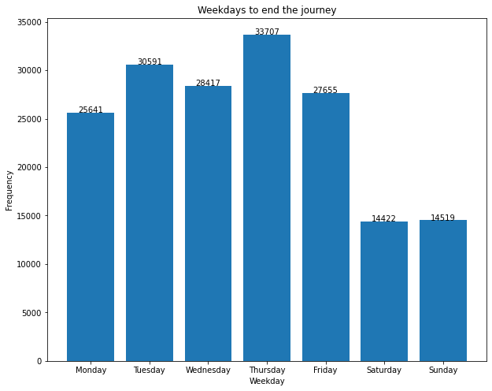

```python
plt_bar_chart(end_wk,'Weekday','Count')
plt.title('Weekdays to end the journey')
plt.xlabel('Weekday')
plt.ylabel('Frequency')
locs, labels= plt.xticks()
for loc in locs:
    # get the text property for the label to get the correct count
    count = end_wk['Count'][loc]
    pct_string = f'{count}'
    # print the annotation just below the top of the bar
    plt.text(loc, count, pct_string, ha = 'center', color = 'black')
plt.show()
```

Looking at the weekdays to start and end the journey, it can be seen that Thursday was the day majority of people started the bike trip and also the day majority of people ended the trip

```python
fordbike_uni.describe()
```

|  | duration_sec | age | start_month | end_month |
| --- | --- | --- | --- | --- |
| count | 174952.000000 | 174952.000000 | 174952.0 | 174952.000000 |
| mean | 704.002744 | 34.196865 | 2.0 | 2.000080 |
| std | 1642.204905 | 10.118731 | 0.0 | 0.008945 |
| min | 61.000000 | 18.000000 | 2.0 | 2.000000 |
| 25% | 323.000000 | 27.000000 | 2.0 | 2.000000 |
| 50% | 510.000000 | 32.000000 | 2.0 | 2.000000 |
| 75% | 789.000000 | 39.000000 | 2.0 | 2.000000 |
| max | 84548.000000 | 141.000000 | 2.0 | 3.000000 |

#### Duration Seconds

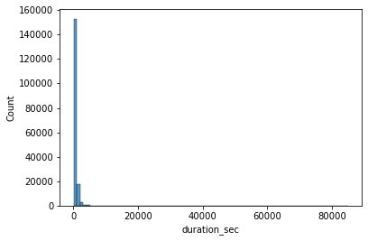

```python
# plotting a quick histogram plot of the duration attribute in the dataset
d_min = fordbike_uni['duration_sec'].min()
d_max = fordbike_uni['duration_sec'].max()
bins = np.arange(d_min,d_max+1000,1000)
sb.histplot(data=fordbike_uni,x='duration_sec',bins=bins);
```

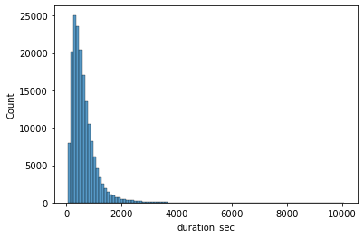

```python
# reducing the max size to 10000 for a better zoom on the plot
bins = np.arange(d_min,10000+100,100)
sb.histplot(data=fordbike_uni,x='duration_sec',bins=bins);
```

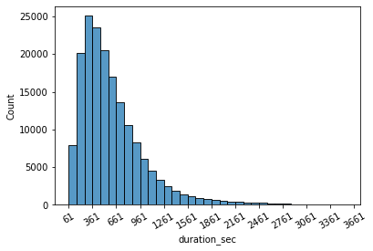

```python
# further reducing the max size to 3500 as majority of the data is constrained below it. This will fully zoom into the plot
bins = np.arange(d_min,3500+100,100)
ticks = np.arange(d_min,3500+300,300)
sb.histplot(data=fordbike_uni,x='duration_sec',bins=bins)
plt.xticks(ticks,rotation=30)
plt.show()
```

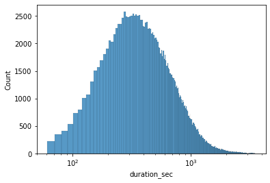

```python
#changing the scale of the x-axis to logscale
bins = np.arange(d_min,3500+10,10)
sb.histplot(data=fordbike_uni,x='duration_sec',bins=bins);
plt.xscale('log')
```

This shows a bell shape indicating it is unimodal

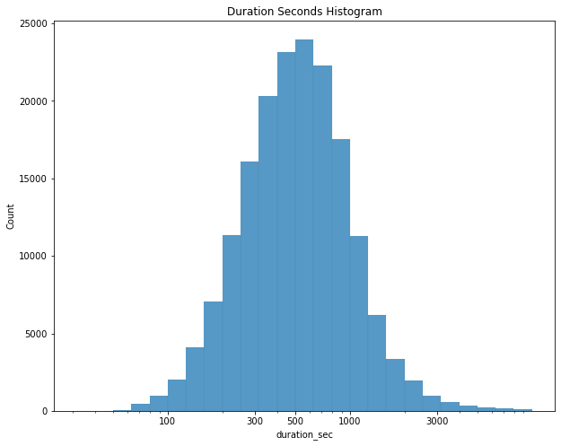

```python
# converting the bin size to log form and plotting the histogram with x-axis transformed to logarithmic form
plt.figure(figsize=(10,8))
bins = 10 ** np.arange(1.5,4+0.1,0.1)
ticks = [100,300,500,1000,3000]
labels = ['{}'.format(val) for val in ticks]
sb.histplot(data=fordbike_uni,x='duration_sec',bins=bins)
plt.title('Duration Seconds Histogram')
plt.xscale('log')
plt.xticks(ticks,labels)
plt.show()
```

#### Time series

Exploring the number of journey per day just to see if there is a correlation or not

```python
# creating new dataframe to extrapolate the date and their counts as well as put them in order
dates_st = fordbike_uni['start_time'].dt.date.value_counts().rename_axis('dates').reset_index(name='Count')
dates_st.sort_values('dates',inplace=True)
dates_st.reset_index(inplace=True)
dates_st.drop('index',axis=1,inplace=True)
```

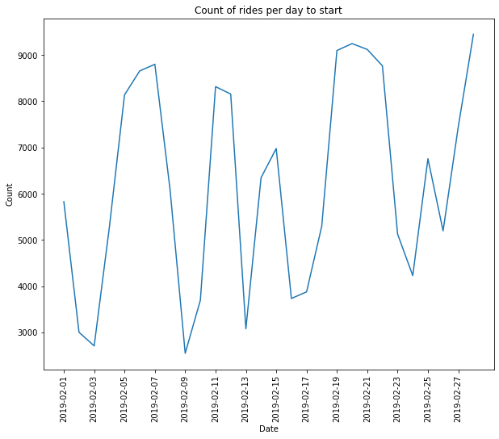

```python
plt.figure(figsize=(10,8))
plt.plot(dates_st['dates'],dates_st['Count'])
plt.xticks(dates_st['dates'][::2],rotation=90) #spacing the labeling to every 2 days in the month
plt.title('Count of rides per day to start')
plt.xlabel('Date')
plt.ylabel('Count')
plt.show()
```

```python
fordbike_uni.head()
```

|  | duration_sec | start_time | end_time | start_station_name | end_station_name | user_type | age | member_gender | bike_share_for_all_trip | start_month | end_month | start_weekday | end_weekday |
| --- | --- | --- | --- | --- | --- | --- | --- | --- | --- | --- | --- | --- | --- |
| 0 | 52185 | 2019-02-28 17:32:10.145 | 2019-03-01 08:01:55.975 | Montgomery St BART Station (Market St at 2nd St) | Commercial St at Montgomery St | Customer | 35 | Male | No | 2 | 3 | Thursday | Friday |
| 1 | 61854 | 2019-02-28 12:13:13.218 | 2019-03-01 05:24:08.146 | Market St at Dolores St | Powell St BART Station (Market St at 4th St) | Customer | 47 | Male | No | 2 | 3 | Thursday | Friday |
| 2 | 36490 | 2019-02-28 17:54:26.010 | 2019-03-01 04:02:36.842 | Grove St at Masonic Ave | Central Ave at Fell St | Subscriber | 30 | Other | No | 2 | 3 | Thursday | Friday |
| 3 | 1585 | 2019-02-28 23:54:18.549 | 2019-03-01 00:20:44.074 | Frank H Ogawa Plaza | 10th Ave at E 15th St | Subscriber | 45 | Male | Yes | 2 | 3 | Thursday | Friday |
| 4 | 1793 | 2019-02-28 23:49:58.632 | 2019-03-01 00:19:51.760 | 4th St at Mission Bay Blvd S | Broadway at Kearny | Subscriber | 60 | Male | No | 2 | 3 | Thursday | Friday |

#### Age

Exploring the age distribution in the dataset

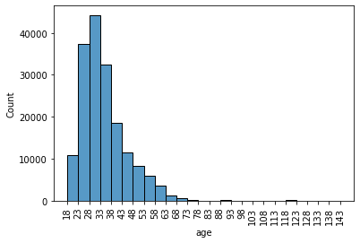

```python
age_min = fordbike_uni['age'].min()
age_max = fordbike_uni['age'].max()
bins = np.arange(age_min,age_max+5,5)
sb.histplot(data=fordbike_uni,x='age',bins=bins)
plt.xticks(bins,rotation=90)
plt.show()
```

From this we can observe that the majority of individuals can be found within the ages 23 and 38 which the highest been between ages 28 and 33

## Bivariate Exploration

```python
#creating copy for bivariate exploration

fordbike_biv = fordbike.copy()
```

```python
fordbike_biv.head()
```

|  | duration_sec | start_time | end_time | start_station_name | end_station_name | user_type | age | member_gender | bike_share_for_all_trip | start_month | end_month | start_weekday | end_weekday |
| --- | --- | --- | --- | --- | --- | --- | --- | --- | --- | --- | --- | --- | --- |
| 0 | 52185 | 2019-02-28 17:32:10.145 | 2019-03-01 08:01:55.975 | Montgomery St BART Station (Market St at 2nd St) | Commercial St at Montgomery St | Customer | 35 | Male | No | 2 | 3 | Thursday | Friday |
| 1 | 61854 | 2019-02-28 12:13:13.218 | 2019-03-01 05:24:08.146 | Market St at Dolores St | Powell St BART Station (Market St at 4th St) | Customer | 47 | Male | No | 2 | 3 | Thursday | Friday |
| 2 | 36490 | 2019-02-28 17:54:26.010 | 2019-03-01 04:02:36.842 | Grove St at Masonic Ave | Central Ave at Fell St | Subscriber | 30 | Other | No | 2 | 3 | Thursday | Friday |
| 3 | 1585 | 2019-02-28 23:54:18.549 | 2019-03-01 00:20:44.074 | Frank H Ogawa Plaza | 10th Ave at E 15th St | Subscriber | 45 | Male | Yes | 2 | 3 | Thursday | Friday |
| 4 | 1793 | 2019-02-28 23:49:58.632 | 2019-03-01 00:19:51.760 | 4th St at Mission Bay Blvd S | Broadway at Kearny | Subscriber | 60 | Male | No | 2 | 3 | Thursday | Friday |

```python
# Functions for bivariate

def biv_plot(type,data,x,y):
    plt.figure(figsize=(10,8))
    if type =='violin':
        sb.violinplot(data=data,x=x,y=y,inner=None)
    elif type == 'box':
        sb.boxplot(data=data,x=x,y=y)
    elif type =='bar':
        sb.countplot(data=data,x=x,hue=y)
```

#### Distribution of the Age for user type

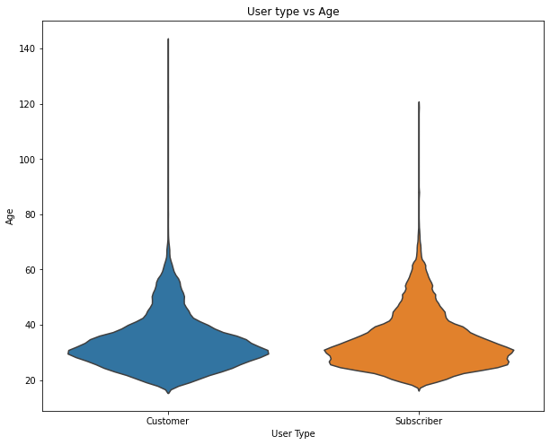

```python
#plotting a violin plot
biv_plot('violin',fordbike_biv,'user_type','age')
plt.title('User type vs Age')
plt.xlabel('User Type')
plt.ylabel('Age')
plt.show()
```

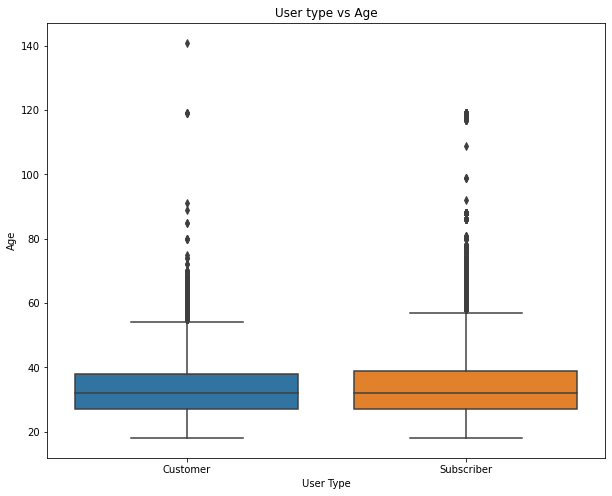

```python
#plotting box plot
biv_plot('box',fordbike_biv,'user_type','age')
plt.title('User type vs Age')
plt.xlabel('User Type')
plt.ylabel('Age')
plt.show()
```

By plotting the box and violin plot of the user type against age, we can see that both types of users (subscriber and customer) seem to have majority found around the same age range and their median on average are very much close if not the same

#### Gender vs Age

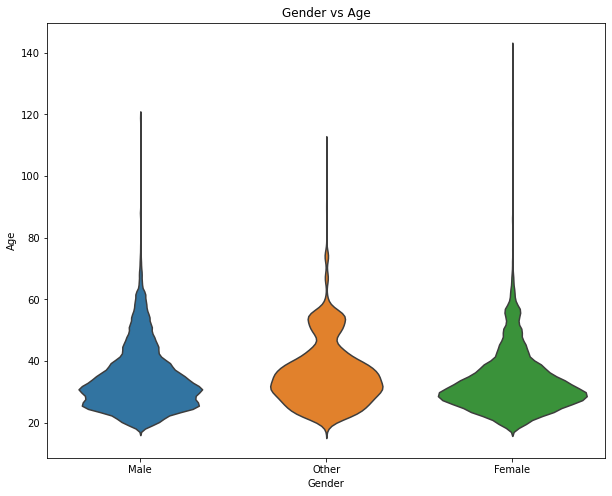

```python
biv_plot('violin',fordbike_biv,'member_gender','age')
plt.title('Gender vs Age')
plt.xlabel('Gender')
plt.ylabel('Age')
plt.show()
```

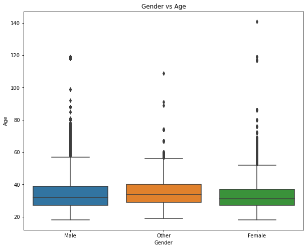

```python
biv_plot('box',fordbike_biv,'member_gender','age')
plt.title('Gender vs Age')
plt.xlabel('Gender')
plt.ylabel('Age')
plt.show()
```

This plots tell us that the although all genders are around the same age range, those in the other gender seem to be slightly older on average

#### Age vs Duration

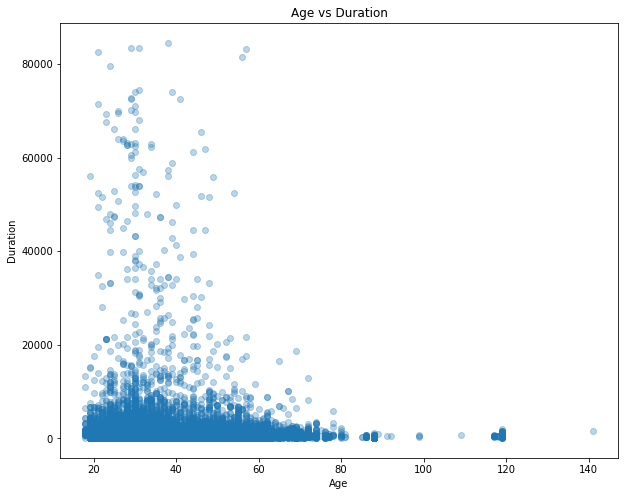

```python
plt.figure(figsize=(10,8))
plt.scatter(data=fordbike_biv,x='age',y='duration_sec',alpha=0.3)
plt.title('Age vs Duration')
plt.xlabel('Age')
plt.ylabel('Duration')
plt.show()
```

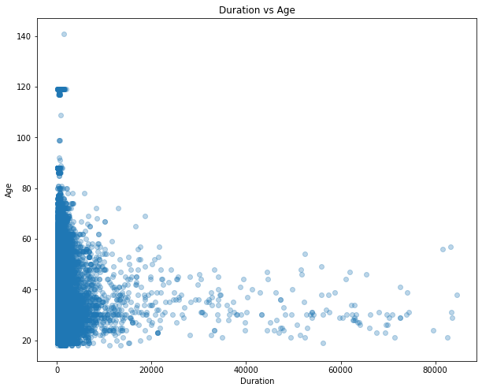

```python
#switching the axis
plt.figure(figsize=(10,8))
plt.scatter(data=fordbike_biv,y='age',x='duration_sec',alpha=0.3)
plt.title('Duration vs Age')
plt.ylabel('Age')
plt.xlabel('Duration')
plt.show()
```

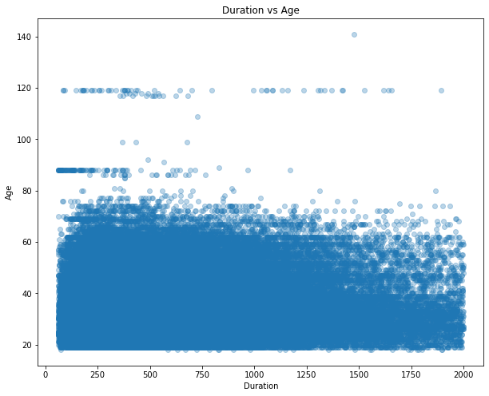

```python
#reducing the dataset size to zoom into the colored area in the above visualisation
small_df = fordbike_biv[fordbike_biv['duration_sec']<2000]
plt.figure(figsize=(10,8))
plt.scatter(data=small_df,y='age',x='duration_sec',alpha=0.3)
plt.title('Duration vs Age')
plt.ylabel('Age')
plt.xlabel('Duration')
plt.show()
```

From the scatter plots between age and duration, we can see that a lot are clustered below 20,000; however looking at the plot as a whole there one can see that as the duration increases the age reduces and those found between the ages 20 and 60 can be found performing this long duration of trips

#### Gender vs Duration

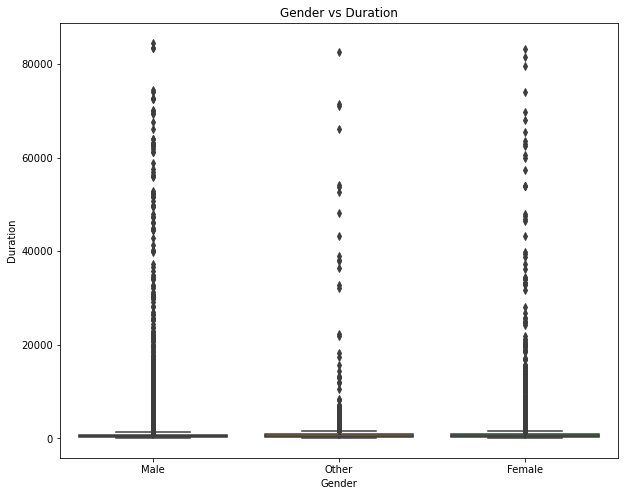

```python
# plotting a box plot
biv_plot('box',fordbike_biv,'member_gender','duration_sec')
plt.title('Gender vs Duration')
plt.ylabel('Duration')
plt.xlabel('Gender')
plt.show()
```

From the univariate plot of the duration_sec attribute, it was noticed that majority can be found below 3500, thus it will be best to extract bits of the data that meet this criteria as the rest can be seen as anomalies and thus affect the plot

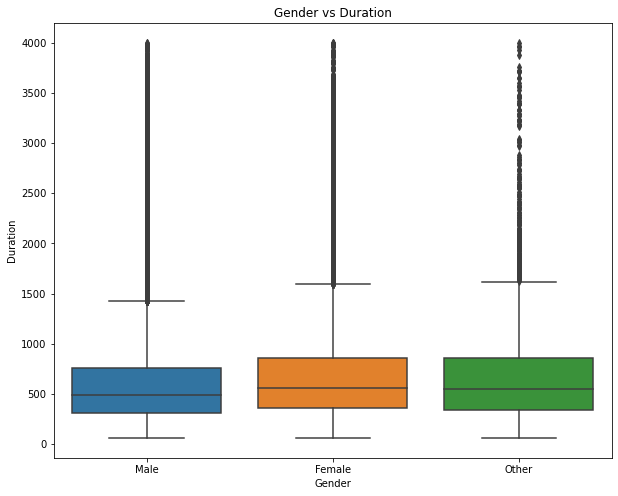

```python
# selecting rows in the dataset that meet the criteria of duration sec below 5000
new_df = fordbike_biv[fordbike_biv['duration_sec']<4000]
biv_plot('box',new_df,'member_gender','duration_sec')
plt.title('Gender vs Duration')
plt.ylabel('Duration')
plt.xlabel('Gender')
plt.show()
```

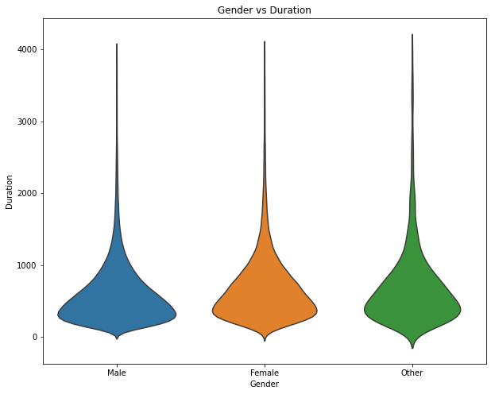

```python
biv_plot('violin',new_df,'member_gender','duration_sec')
plt.title('Gender vs Duration')
plt.ylabel('Duration')
plt.xlabel('Gender')
plt.show()
```

This is a much better plot and zooms into the information we have. From the plot it would seem that on average the Female and other gender went on the bike trip for much longer than the Male gender

#### User type vs Duration

Just like when examining Gender distribution for the duration where the dataset was reduced due to the majority been found below 4000 with the rest set as anomalies, the same will be applied while replacing gender with user type attribute using the dataset created already

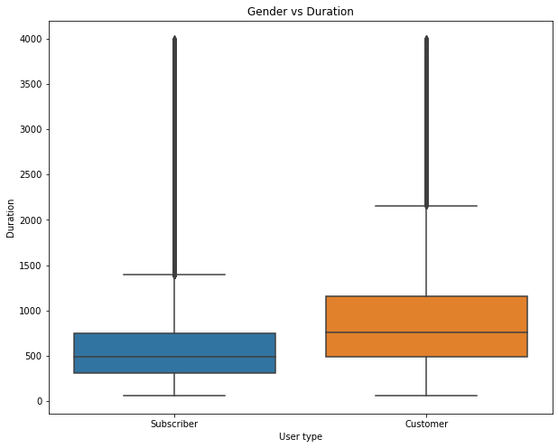

```python
biv_plot('box',new_df,'user_type','duration_sec')
plt.title('Gender vs Duration')
plt.ylabel('Duration')
plt.xlabel('User type')
plt.show()
```

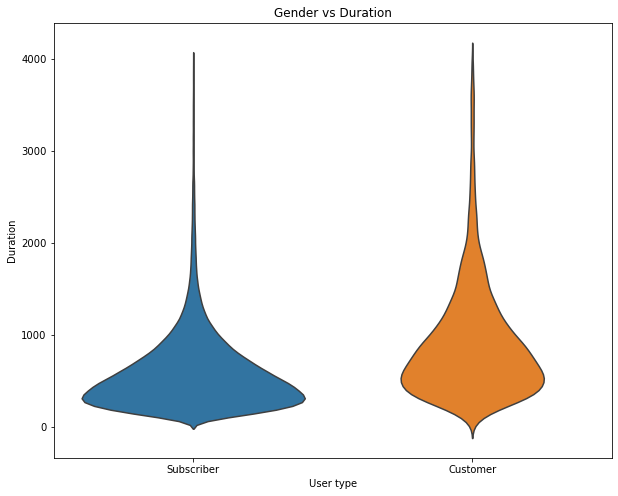

```python
biv_plot('violin',new_df,'user_type','duration_sec')
plt.title('Gender vs Duration')
plt.ylabel('Duration')
plt.xlabel('User type')
plt.show()
```

This plot shows that on average, users that were customers went on trips for a longer duration than subscribers despite subscribers been significantly more

#### Gender and User type

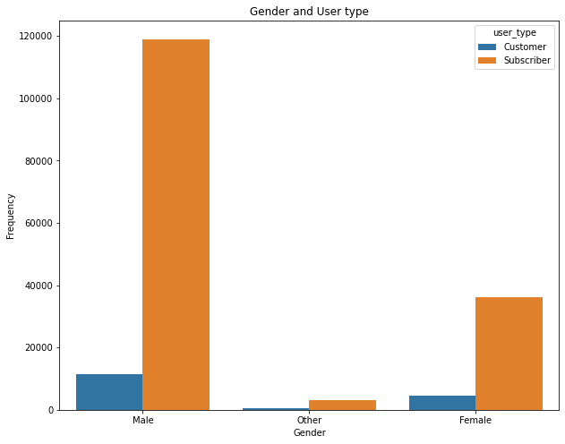

```python
#sb.countplot(data=fordbike_biv,x='member_gender',hue='user_type',order=['Male','Female','Other']);
biv_plot('bar',fordbike_biv,'member_gender','user_type')
plt.title('Gender and User type')
plt.xlabel('Gender')
plt.ylabel('Frequency')
plt.show()
```

#### Bike share and User type

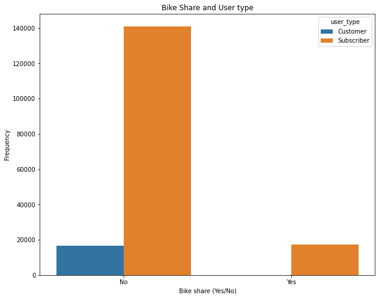

```python
biv_plot('bar',fordbike_biv,'bike_share_for_all_trip','user_type')
plt.title('Bike Share and User type')
plt.xlabel('Bike share (Yes/No)')
plt.ylabel('Frequency')
plt.show()
```

With the 2 plots above we are able to see what ratio of user type for each gender and for bike share. It can be seen that for the bike share, all the customer type users indicated to no and not one indicated yes

#### Weekday and Duration

For this, the end_weekday was explored as that is the day that the individual would have finished their trip and accumulated all the duration seconds. With this we can see which day had most duration rather than number of individuals that finished that day as seen in the univariate exploration

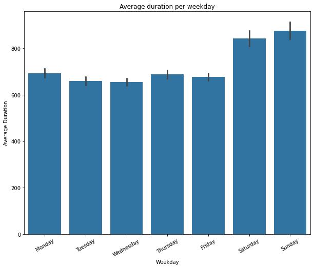

```python
plt.figure(figsize=(10,8))
# creating an order for the days of the week
days=['Monday','Tuesday','Wednesday','Thursday','Friday','Saturday','Sunday']

#plotting using barplot from the seaborn library
chart_col = sb.color_palette()[0]
sb.barplot(data=fordbike_biv,x='end_weekday',y='duration_sec',order=days,color=chart_col)
plt.title('Average duration per weekday')
plt.xlabel('Weekday')
plt.ylabel('Average Duration')
plt.xticks(rotation=30)
plt.show()
```

From this we can see that the most time spent on a trip was actually on the weekend most especially on Sunday. This would resonate with the fact that more people will have more free time then to actually go for a bike ride and spend longer.

## Multivariate Exploration

```python
#copy of fordbike data
fordbike_mul = fordbike_biv.copy()
```

```python
fordbike_mul.head(2)
```

|  | duration_sec | start_time | end_time | start_station_name | end_station_name | user_type | age | member_gender | bike_share_for_all_trip | start_month | end_month | start_weekday | end_weekday |
| --- | --- | --- | --- | --- | --- | --- | --- | --- | --- | --- | --- | --- | --- |
| 0 | 52185 | 2019-02-28 17:32:10.145 | 2019-03-01 08:01:55.975 | Montgomery St BART Station (Market St at 2nd St) | Commercial St at Montgomery St | Customer | 35 | Male | No | 2 | 3 | Thursday | Friday |
| 1 | 61854 | 2019-02-28 12:13:13.218 | 2019-03-01 05:24:08.146 | Market St at Dolores St | Powell St BART Station (Market St at 4th St) | Customer | 47 | Male | No | 2 | 3 | Thursday | Friday |

```python
#Functions for multivariate

def mul_plot(data,x,y,h):
    plt.figure(figsize=(10,8))
    sb.lmplot(data=data,y=y,x=x,hue=h,fit_reg=False)
```

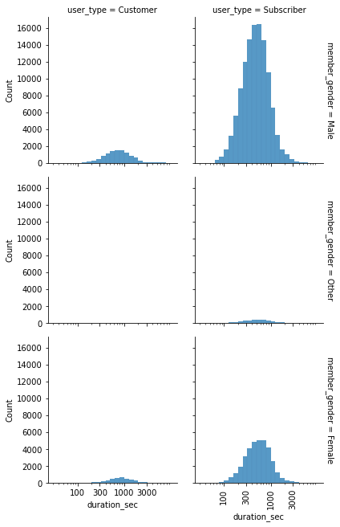

```python
bins = 10 ** np.arange(1.5,4+0.1,0.1)
ticks = [100,300,1000,3000]
labels = ['{}'.format(val) for val in ticks]
#sb.histplot(data=fordbike_uni,x='duration_sec',bins=bins)
g = sb.FacetGrid(data=fordbike_mul,col='user_type',row='member_gender',margin_titles=True)
g.map(sb.histplot,'duration_sec',bins=bins)
plt.xscale('log')
plt.xticks(ticks,labels,rotation=90)
plt.show()
```

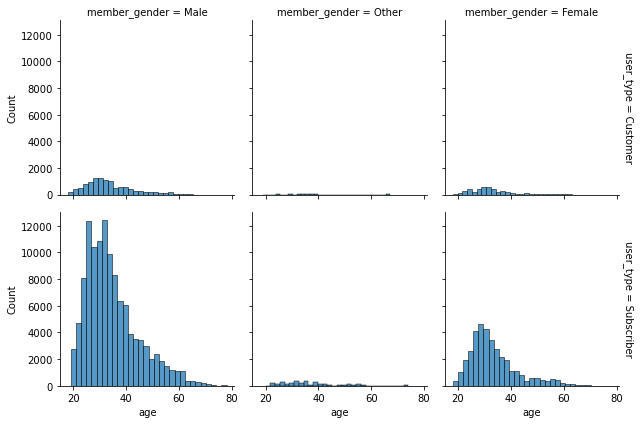

```python
#sb.histplot(data=fordbike_uni,x='duration_sec',bins=bins)
#plt.figure(figsize=(10,10))
test_df = fordbike_mul[fordbike_mul['age']<80]
f = sb.FacetGrid(data=test_df,col='member_gender',row='user_type',margin_titles=True)
f.map(sb.histplot,'age',bins=30)
plt.show()
```

Exploring Age and Duration using different 3 variables to color

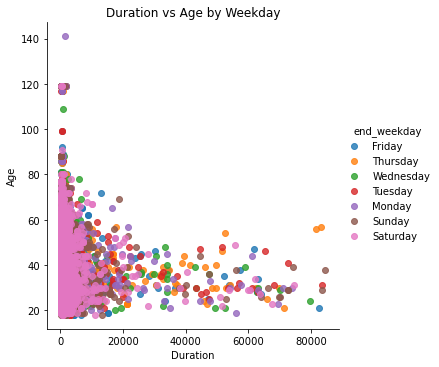

```python
mul_plot(fordbike_mul,'duration_sec','age','end_weekday')
plt.title('Duration vs Age by Weekday')
plt.xlabel('Duration')
plt.ylabel('Age')
plt.show()
```

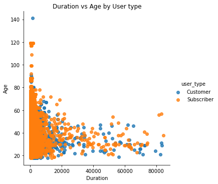

```python
mul_plot(fordbike_mul,'duration_sec','age','user_type')
plt.title('Duration vs Age by User type')
plt.xlabel('Duration')
plt.ylabel('Age')
plt.show()
```

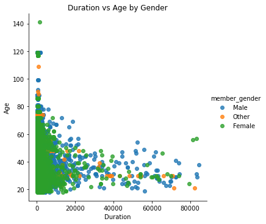

```python
mul_plot(fordbike_mul,'duration_sec','age','member_gender')
plt.title('Duration vs Age by Gender')
plt.xlabel('Duration')
plt.ylabel('Age')
plt.show()
```

These plots were plotted to look at a third variable within the age vs duration scatterplot. However, not much can be made from them as they do not showcase any new information which is already known.

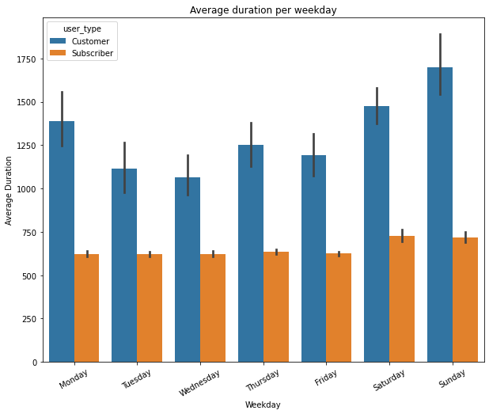

```python
plt.figure(figsize=(10,8))
# creating an order for the days of the week
days=['Monday','Tuesday','Wednesday','Thursday','Friday','Saturday','Sunday']

#plotting using barplot from the seaborn library
#chart_col = sb.color_palette()[0]
sb.barplot(data=fordbike_biv,x='end_weekday',y='duration_sec',hue='user_type',order=days)
plt.title('Average duration per weekday')
plt.xlabel('Weekday')
plt.ylabel('Average Duration')
plt.xticks(rotation=30)
plt.show()
```

This plot further supports the box plot drawn during the bivariate exploration, where it was noticed that on average the customer users biked or went on their trips for a much longer duration in comparison to the subscriber users

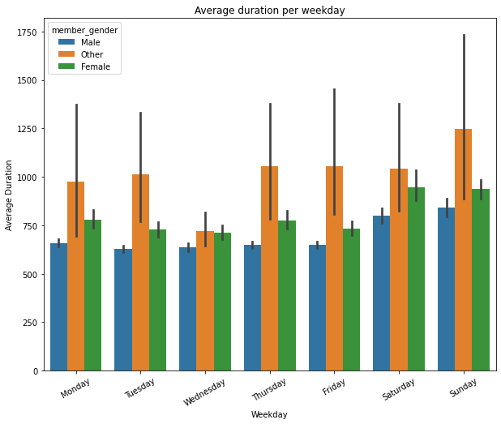

```python
plt.figure(figsize=(10,8))
# creating an order for the days of the week
days=['Monday','Tuesday','Wednesday','Thursday','Friday','Saturday','Sunday']

#plotting using barplot from the seaborn library
#chart_col = sb.color_palette()[0]
sb.barplot(data=fordbike_biv,x='end_weekday',y='duration_sec',hue='member_gender',order=days)
plt.title('Average duration per weekday')
plt.xlabel('Weekday')
plt.ylabel('Average Duration')
plt.xticks(rotation=30)
plt.show()
```

## Conclusions

> Remove all Tips mentioned above, before you convert this notebook to PDF/HTML

> At the end of your report, make sure that you export the notebook as an html file from the `File > Download as... > HTML or PDF` menu. Make sure you keep track of where the exported file goes, so you can put it in the same folder as this notebook for project submission. Also, make sure you remove all of the quote-formatted guide notes like this one before you finish your report!

From all the explorations done, the following were noticed in general